# R Notebook

A. Primero analziamos las correlaicones entre las variables observables y el indice

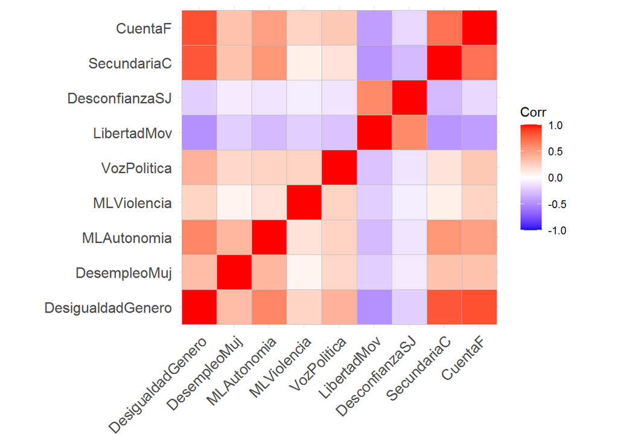

```r
library(polycor)
correlaciones=polycor::hetcor(subdata[,-c(1,11,12,13)])$correlations
#Sin evaluar significancia:
library(ggcorrplot)
ggcorrplot(correlaciones)
```

```r
correlaciones
```

```
##                   DesigualdadGenero DesempleoMuj MLAutonomia MLViolencia
## DesigualdadGenero         1.0000000   0.35393759   0.6053820  0.21939026
## DesempleoMuj              0.3539376   1.00000000   0.3798929  0.06311283
## MLAutonomia               0.6053820   0.37989285   1.0000000  0.15421933
## MLViolencia               0.2193903   0.06311283   0.1542193  1.00000000
## VozPolitica               0.4001370   0.20921218   0.2322180  0.22665338
## LibertadMov              -0.4782063  -0.19660582  -0.2961173 -0.20081518
## DesconfianzaSJ           -0.2047731  -0.08814631  -0.1175670 -0.08173408
## SecundariaC               0.8083740   0.30574213   0.5392837  0.07506195
## CuentaF                   0.8444657   0.31370692   0.4890307  0.22699472
##                   VozPolitica LibertadMov DesconfianzaSJ SecundariaC    CuentaF
## DesigualdadGenero   0.4001370  -0.4782063    -0.20477309  0.80837400  0.8444657
## DesempleoMuj        0.2092122  -0.1966058    -0.08814631  0.30574213  0.3137069
## MLAutonomia         0.2322180  -0.2961173    -0.11756698  0.53928370  0.4890307
## MLViolencia         0.2266534  -0.2008152    -0.08173408  0.07506195  0.2269947
## VozPolitica         1.0000000  -0.2563084    -0.12122757  0.14627576  0.2889660
## LibertadMov        -0.2563084   1.0000000     0.58969916 -0.46089464 -0.4158157
## DesconfianzaSJ     -0.1212276   0.5896992     1.00000000 -0.30338100 -0.1730212
## SecundariaC         0.1462758  -0.4608946    -0.30338100  1.00000000  0.7104165
## CuentaF             0.2889660  -0.4158157    -0.17302123  0.71041650  1.0000000
```

#REGRESION CON CADA VARIABLE

```r
mod1=lm(subdata$DesigualdadGenero ~ subdata$MLAutonomia)
summary(mod1)
```

```
##
## Call:
## lm(formula = subdata$DesigualdadGenero ~ subdata$MLAutonomia)
##
## Residuals:
##     Min      1Q  Median      3Q     Max
## -49.333 -15.155  -0.435  12.549  49.728
##
## Coefficients:
##                     Estimate Std. Error t value Pr(>|t|)
## (Intercept)           11.971      3.754   3.189  0.00183 **
## subdata$MLAutonomia   10.923      1.316   8.297  1.9e-13 ***
## ---
## Signif. codes:  0 '***' 0.001 '**' 0.01 '*' 0.05 '.' 0.1 ' ' 1
##
## Residual standard error: 20.4 on 119 degrees of freedom
## Multiple R-squared:  0.3665, Adjusted R-squared:  0.3612
## F-statistic: 68.84 on 1 and 119 DF,  p-value: 1.904e-13
```

```r
mod2=lm(subdata$DesigualdadGenero ~ subdata$MLViolencia)
summary(mod2)
```

```
##
## Call:
## lm(formula = subdata$DesigualdadGenero ~ subdata$MLViolencia)
##
## Residuals:
##     Min      1Q  Median      3Q     Max
## -43.910 -23.657   2.925  22.340  56.090
##
## Coefficients:
##                     Estimate Std. Error t value Pr(>|t|)
## (Intercept)           23.641      6.681   3.538 0.000575 ***
## subdata$MLViolencia    6.756      2.754   2.453 0.015616 *
## ---
## Signif. codes:  0 '***' 0.001 '**' 0.01 '*' 0.05 '.' 0.1 ' ' 1
##
## Residual standard error: 25.01 on 119 degrees of freedom
## Multiple R-squared:  0.04813,    Adjusted R-squared:  0.04013
## F-statistic: 6.017 on 1 and 119 DF,  p-value: 0.01562
```

```r
mod3=lm(subdata$DesigualdadGenero ~ subdata$VozPolitica)
summary(mod3)
```

```
##
## Call:
## lm(formula = subdata$DesigualdadGenero ~ subdata$VozPolitica)
##
## Residuals:
##     Min      1Q  Median      3Q     Max
## -43.737 -21.909   1.139  20.972  41.824
##
## Coefficients:
##                     Estimate Std. Error t value Pr(>|t|)
## (Intercept)         -28.1085    14.2616  -1.971   0.0511 .
## subdata$VozPolitica   0.8837     0.1855   4.763 5.43e-06 ***
## ---
## Signif. codes:  0 '***' 0.001 '**' 0.01 '*' 0.05 '.' 0.1 ' ' 1
##
## Residual standard error: 23.49 on 119 degrees of freedom
## Multiple R-squared:  0.1601, Adjusted R-squared:  0.1531
## F-statistic: 22.69 on 1 and 119 DF,  p-value: 5.434e-06
```

```r
mod4=lm(subdata$DesigualdadGenero ~ subdata$LibertadMov)
summary(mod4)
```

```
##
## Call:
## lm(formula = subdata$DesigualdadGenero ~ subdata$LibertadMov)
##
## Residuals:
##    Min     1Q Median     3Q    Max
## -49.87 -15.87   3.35  16.24  66.07
##
## Coefficients:
##                     Estimate Std. Error t value Pr(>|t|)
## (Intercept)         112.4130    12.5191   8.979 4.86e-15 ***
## subdata$LibertadMov  -1.1542     0.1943  -5.940 2.90e-08 ***
## ---
## Signif. codes:  0 '***' 0.001 '**' 0.01 '*' 0.05 '.' 0.1 ' ' 1
##
## Residual standard error: 22.51 on 119 degrees of freedom
## Multiple R-squared:  0.2287, Adjusted R-squared:  0.2222
## F-statistic: 35.28 on 1 and 119 DF,  p-value: 2.902e-08
```

```r
mod5=lm(subdata$DesigualdadGenero ~ subdata$Desconfianza)
summary(mod5)
```

```
##
## Call:
## lm(formula = subdata$DesigualdadGenero ~ subdata$Desconfianza)
##
## Residuals:
##     Min      1Q  Median      3Q     Max
## -45.867 -25.837   6.091  19.418  55.116
##
## Coefficients:
##                      Estimate Std. Error t value Pr(>|t|)
## (Intercept)           72.8243    14.9730   4.864 3.56e-06 ***
## subdata$Desconfianza  -0.6559     0.2874  -2.282   0.0243 *
## ---
## Signif. codes:  0 '***' 0.001 '**' 0.01 '*' 0.05 '.' 0.1 ' ' 1
##
## Residual standard error: 25.09 on 119 degrees of freedom
## Multiple R-squared:  0.04193,    Adjusted R-squared:  0.03388
## F-statistic: 5.208 on 1 and 119 DF,  p-value: 0.02426
```

```r
mod6=lm(subdata$DesigualdadGenero ~ subdata$DesempleoMuj)
summary(mod6)
```

```
##
## Call:
## lm(formula = subdata$DesigualdadGenero ~ subdata$DesempleoMuj)
##
## Residuals:
##     Min      1Q  Median      3Q     Max
## -37.499 -21.618   0.946  16.357  55.164
##
## Coefficients:
##                      Estimate Std. Error t value Pr(>|t|)
## (Intercept)            10.523      7.246   1.452    0.149
## subdata$DesempleoMuj   23.056      5.585   4.128 6.82e-05 ***
## ---
## Signif. codes:  0 '***' 0.001 '**' 0.01 '*' 0.05 '.' 0.1 ' ' 1
##
## Residual standard error: 23.97 on 119 degrees of freedom
## Multiple R-squared:  0.1253, Adjusted R-squared:  0.1179
## F-statistic: 17.04 on 1 and 119 DF,  p-value: 6.816e-05
```

```r
mod7=lm(subdata$DesigualdadGenero ~ subdata$SecundariaC)
summary(mod7)
```

```
##
## Call:
## lm(formula = subdata$DesigualdadGenero ~ subdata$SecundariaC)
##
## Residuals:
##     Min      1Q  Median      3Q     Max
## -39.485 -10.301   0.253   9.253  34.020
##
## Coefficients:
##                     Estimate Std. Error t value Pr(>|t|)
## (Intercept)         12.03141    2.26614   5.309 5.19e-07 ***
## subdata$SecundariaC  0.68660    0.04583  14.980  < 2e-16 ***
## ---
## Signif. codes:  0 '***' 0.001 '**' 0.01 '*' 0.05 '.' 0.1 ' ' 1
##
## Residual standard error: 15.09 on 119 degrees of freedom
## Multiple R-squared:  0.6535, Adjusted R-squared:  0.6506
## F-statistic: 224.4 on 1 and 119 DF,  p-value: < 2.2e-16
```

```r
mod8=lm(subdata$DesigualdadGenero ~ subdata$CuentaF)
summary(mod8)
```

```
##
## Call:
## lm(formula = subdata$DesigualdadGenero ~ subdata$CuentaF)
##
## Residuals:
##     Min      1Q  Median      3Q     Max
## -29.465  -8.560  -2.987   9.681  39.279
##
## Coefficients:
##                 Estimate Std. Error t value Pr(>|t|)
## (Intercept)      7.45529    2.22100   3.357  0.00106 **
## subdata$CuentaF  0.74411    0.04326  17.199  < 2e-16 ***
## ---
## Signif. codes:  0 '***' 0.001 '**' 0.01 '*' 0.05 '.' 0.1 ' ' 1
##
## Residual standard error: 13.73 on 119 degrees of freedom
## Multiple R-squared:  0.7131, Adjusted R-squared:  0.7107
## F-statistic: 295.8 on 1 and 119 DF,  p-value: < 2.2e-16
```

13. MODELOS FINALES DE REGRESION

```r
MF0=lm(DesigualdadGenero ~ .,data=subdata[,-c(1)])
summary(MF0)
```

```
##
## Call:
## lm(formula = DesigualdadGenero ~ ., data = subdata[, -c(1)])
##
## Residuals:
##      Min       1Q   Median       3Q      Max
## -22.3655  -6.6794  -0.4966   5.7559  29.0788
##
## Coefficients: (3 not defined because of singularities)
##                 Estimate Std. Error t value Pr(>|t|)
## (Intercept)    -27.67818   11.35763  -2.437  0.01639 *
## DesempleoMuj     0.39520    2.60303   0.152  0.87960
## MLAutonomia      2.21140    0.82439   2.682  0.00841 **
## MLViolencia      0.78846    1.18418   0.666  0.50689
## VozPolitica      0.38295    0.08741   4.381 2.67e-05 ***
## LibertadMov     -0.17300    0.12133  -1.426  0.15670
## DesconfianzaSJ   0.22505    0.14623   1.539  0.12662
## SecundariaC      0.33900    0.04930   6.876 3.69e-10 ***
## CuentaF          0.37494    0.04910   7.636 8.11e-12 ***
## factor1               NA         NA      NA       NA
## factor2               NA         NA      NA       NA
## factor3               NA         NA      NA       NA
## ---
## Signif. codes:  0 '***' 0.001 '**' 0.01 '*' 0.05 '.' 0.1 ' ' 1
##
## Residual standard error: 10.12 on 112 degrees of freedom
## Multiple R-squared:  0.8532, Adjusted R-squared:  0.8427
## F-statistic: 81.37 on 8 and 112 DF,  p-value: < 2.2e-16
```

#MODELO 1

```r
MF1=lm(subdata$DesigualdadGenero ~ subdata$MLAutonomia +subdata$LibertadMov + subdata$SecundariaC + subdata$CuentaF)
anova(MF1)
```

|  | Df | Sum Sq | Mean Sq | F value | Pr(>F) |
| --- | --- | --- | --- | --- | --- |
| subdata$MLAutonomia | 1 | 28656.198 | 28656.1978 | 239.67388 | 5.373735e-30 |
| subdata$LibertadMov | 1 | 7659.306 | 7659.3058 | 64.06068 | 1.025714e-12 |
| subdata$SecundariaC | 1 | 18831.452 | 18831.4521 | 157.50195 | 2.403257e-23 |
| subdata$CuentaF | 1 | 9175.214 | 9175.2138 | 76.73939 | 1.877710e-14 |
| Residuals | 116 | 13869.342 | 119.5633 | NA | NA |

```r
library(stargazer)
stargazer(MF1, type = "text")
```

```
##
## ===============================================
##                         Dependent variable:
##                     ---------------------------
##                          DesigualdadGenero
## -----------------------------------------------
## MLAutonomia                  2.883***
##                               (0.852)
##
## LibertadMov                   -0.165
##                               (0.108)
##
## SecundariaC                  0.285***
##                               (0.051)
##
## CuentaF                      0.440***
##                               (0.050)
##
## Constant                      12.498
##                               (7.963)
##
## -----------------------------------------------
## Observations                    121
## R2                             0.823
## Adjusted R2                    0.817
## Residual Std. Error      10.935 (df = 116)
## F Statistic          134.494*** (df = 4; 116)
## ===============================================
## Note:               *p<0.1; **p<0.05; ***p<0.01
```

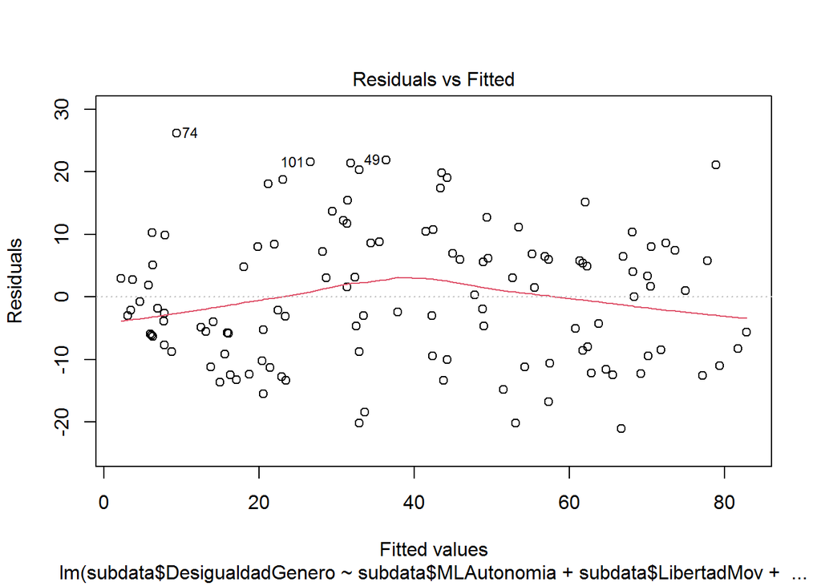

```r
# linea roja debe tender a horizontal
plot(MF1, 1)
```

B. Homocedasticidad Se asume que el error del modelo de regresión no afecta la varianza o dispersión de la estimación (MATH^):

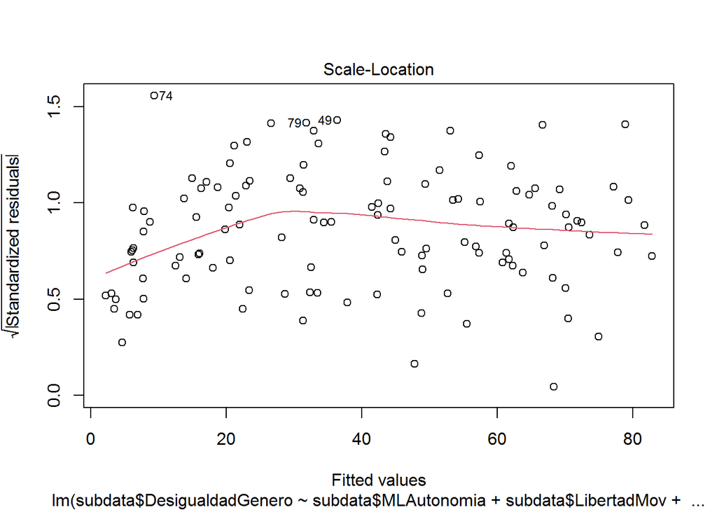

```r
# linea roja debe tender a horizontal
plot(MF1, 3)
```

También podemos utilizar el test de Breusch-Pagan:

```r
library(lmtest)
# Hnull: modelo homocedastico
bptest(MF1)
```

```
##
##  studentized Breusch-Pagan test
##
## data:  MF1
## BP = 2.2368, df = 4, p-value = 0.6923
```

C. Normalidad de los residuos - Los residuos, la diferencia entre MATH y MATH^, debe distribuirse de manera normal:

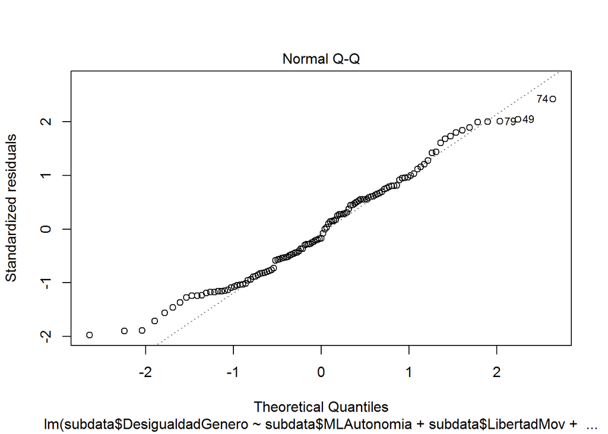

```r
# puntos cerca a la diagonal
plot(MF1, 2)
```

Podemos aplicar el test de Shapiro a los residuos:

```r
shapiro.test(MF1$residuals)
```

```
##
##  Shapiro-Wilk normality test
##
## data:  MF1$residuals
## W = 0.97744, p-value = 0.03981
```

D.No multicolinelidad - Si los predictores tienen una correlación muy alta entre sí, hay multicolinealidad, lo cual no es deseable:

```r
library(DescTools)
VIF(MF1) # > 5 es problematico
```

```
## subdata$MLAutonomia subdata$LibertadMov subdata$SecundariaC     subdata$CuentaF
##            1.458874            1.297679            2.368700            2.122842
```

5. Valores influyentes

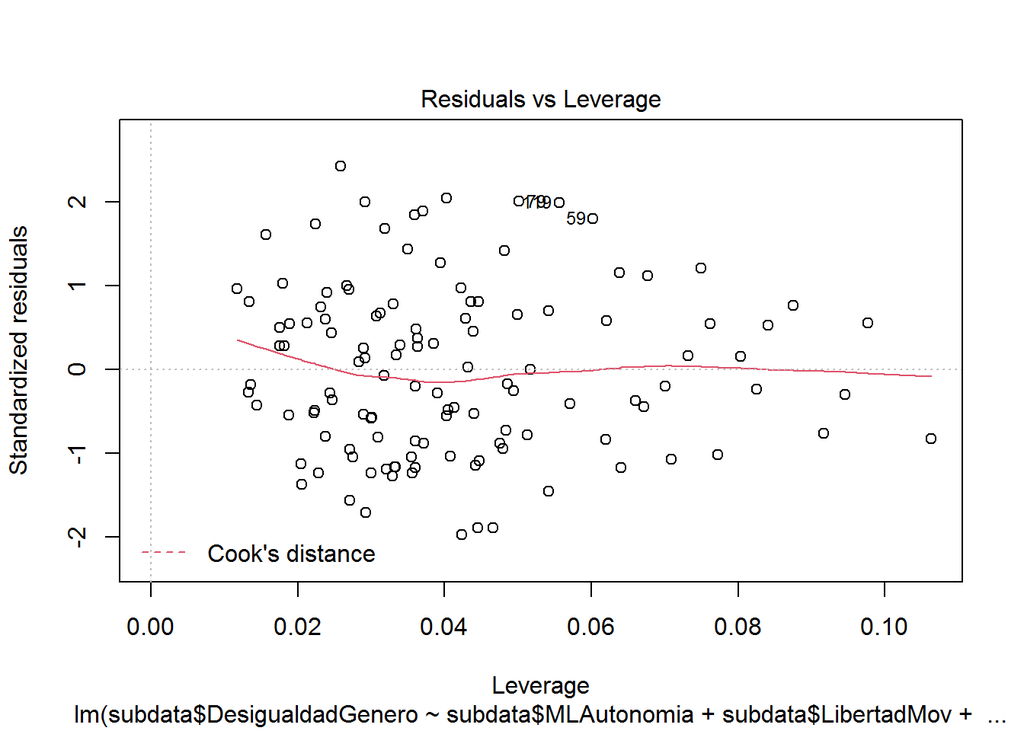

```r
plot(MF1,5)
```

```r
checkMF1=as.data.frame(influence.measures(MF1)$is.inf)
head(checkMF1)
```

|  | dfb.1_ | dfb.s$ML | dfb.s$LM | dfb.s$SC | dfb.s$CF | dffit | cov.r | cook.d | hat |
| --- | --- | --- | --- | --- | --- | --- | --- | --- | --- |
| 1 | FALSE | FALSE | FALSE | FALSE | FALSE | FALSE | FALSE | FALSE | FALSE |
| 2 | FALSE | FALSE | FALSE | FALSE | FALSE | FALSE | FALSE | FALSE | FALSE |
| 3 | FALSE | FALSE | FALSE | FALSE | FALSE | FALSE | FALSE | FALSE | FALSE |
| 4 | FALSE | FALSE | FALSE | FALSE | FALSE | FALSE | FALSE | FALSE | FALSE |
| 5 | FALSE | FALSE | FALSE | FALSE | FALSE | FALSE | FALSE | FALSE | FALSE |
| 6 | FALSE | FALSE | FALSE | FALSE | FALSE | FALSE | FALSE | FALSE | FALSE |

```r
checkMF1[checkMF1$cook.d|checkMF1$hat,]
```

| dfb.1_ | dfb.s$ML | dfb.s$LM | dfb.s$SC | dfb.s$CF | dffit | cov.r | cook.d | hat |
| --- | --- | --- | --- | --- | --- | --- | --- | --- |

#MODELO 2

```r
MF2=lm(subdata$DesigualdadGenero ~ subdata$MLAutonomia +subdata$SecundariaC + subdata$CuentaF+ subdata$VozPolitica)
anova(MF1)
```

|  | Df | Sum Sq | Mean Sq | F value | Pr(>F) |
| --- | --- | --- | --- | --- | --- |
| subdata$MLAutonomia | 1 | 28656.198 | 28656.1978 | 239.67388 | 5.373735e-30 |
| subdata$LibertadMov | 1 | 7659.306 | 7659.3058 | 64.06068 | 1.025714e-12 |
| subdata$SecundariaC | 1 | 18831.452 | 18831.4521 | 157.50195 | 2.403257e-23 |
| subdata$CuentaF | 1 | 9175.214 | 9175.2138 | 76.73939 | 1.877710e-14 |
| Residuals | 116 | 13869.342 | 119.5633 | NA | NA |

```r
stargazer(MF2, type = "text")
```

```
##
## ===============================================
##                         Dependent variable:
##                     ---------------------------
##                          DesigualdadGenero
## -----------------------------------------------
## MLAutonomia                  2.389***
##                               (0.795)
##
## SecundariaC                  0.332***
##                               (0.046)
##
## CuentaF                      0.396***
##                               (0.047)
##
## VozPolitica                  0.403***
##                               (0.085)
##
## Constant                    -27.366***
##                               (6.211)
##
## -----------------------------------------------
## Observations                    121
## R2                             0.849
## Adjusted R2                    0.843
## Residual Std. Error      10.101 (df = 116)
## F Statistic          162.598*** (df = 4; 116)
## ===============================================
## Note:               *p<0.1; **p<0.05; ***p<0.01
```

##DIAGNOSTICO DEL MODELO 2 A.LINEALIDAD - Se asume relación lineal entre Y y X:

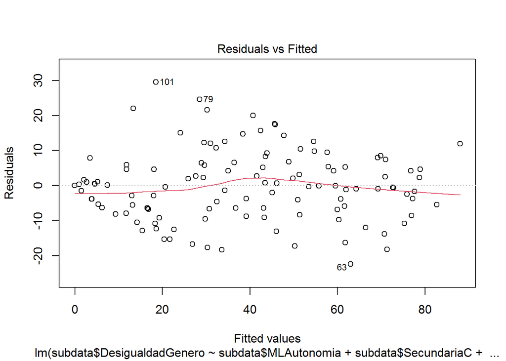

```r
# linea roja debe tender a horizontal
plot(MF2, 1)
```

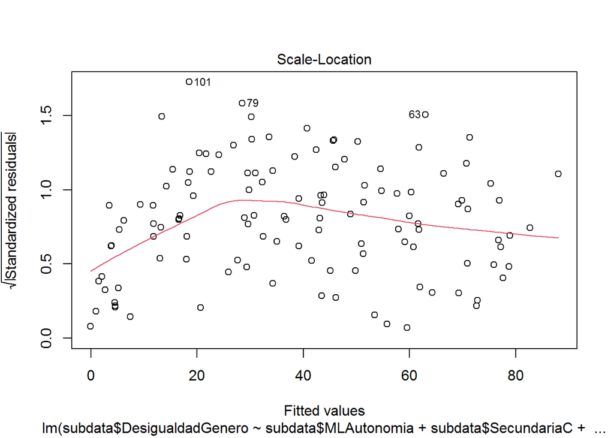

```r
# linea roja debe tender a horizontal
plot(MF2, 3)
```

También podemos utilizar el test de Breusch-Pagan:

```r
library(lmtest)
# Hnull: modelo homocedastico
bptest(MF2)
```

```
##
##  studentized Breusch-Pagan test
##
## data:  MF2
## BP = 3.4828, df = 4, p-value = 0.4805
```

- La probabilidad de homocedasticidad es alta, de el modelo muestra homocedasticidad.

C. Normalidad de los residuos

Los residuos, la diferencia entre MATH y MATH^, debe distribuirse de manera normal:

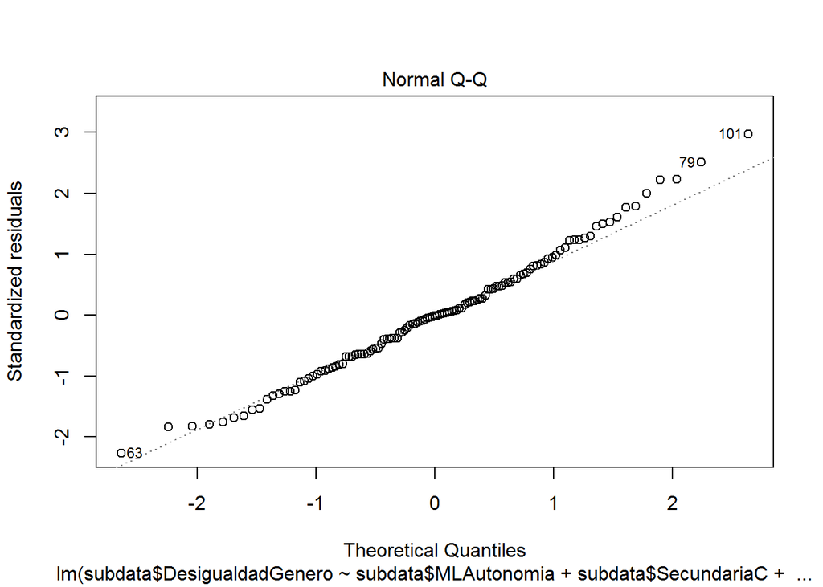

```r
# puntos cerca a la diagonal
plot(MF2, 2)
```

Podemos aplicar el test de Shapiro a los residuos:

```r
shapiro.test(MF2$residuals)
```

```
##
##  Shapiro-Wilk normality test
##
## data:  MF2$residuals
## W = 0.9906, p-value = 0.5825
```

- SI HAY UNS DISTRIBUCION NORMAL

D.No multicolinelidad - Si los predictores tienen una correlación muy alta entre sí, hay multicolinealidad, lo cual no es deseable:

```r
library(DescTools)
VIF(MF2) # > 5 es problematico
```

```
## subdata$MLAutonomia subdata$SecundariaC     subdata$CuentaF subdata$VozPolitica
##            1.487444            2.275256            2.213953            1.122818
```

5. Valores influyentes

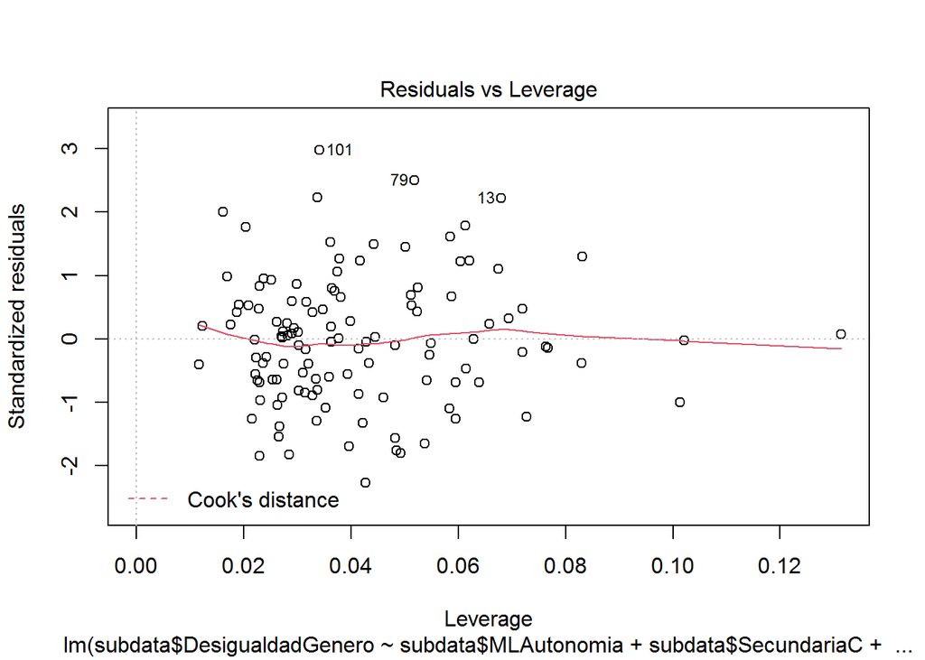

```r
plot(MF2,5)
```

RESPUESTA: segun el grafico hay un indicio que si hay tres casos influyentes pero se verificará tomando en cuenta la distancia cook y el hat.

```r
checkMF2=as.data.frame(influence.measures(MF2)$is.inf)
head(checkMF2)
```

|  | dfb.1_ | dfb.s$ML | dfb.s$SC | dfb.s$CF | dfb.s$VP | dffit | cov.r | cook.d | hat |
| --- | --- | --- | --- | --- | --- | --- | --- | --- | --- |
| 1 | FALSE | FALSE | FALSE | FALSE | FALSE | FALSE | FALSE | FALSE | FALSE |
| 2 | FALSE | FALSE | FALSE | FALSE | FALSE | FALSE | FALSE | FALSE | FALSE |
| 3 | FALSE | FALSE | FALSE | FALSE | FALSE | FALSE | FALSE | FALSE | FALSE |
| 4 | FALSE | FALSE | FALSE | FALSE | FALSE | FALSE | FALSE | FALSE | FALSE |
| 5 | FALSE | FALSE | FALSE | FALSE | FALSE | FALSE | FALSE | FALSE | FALSE |
| 6 | FALSE | FALSE | FALSE | FALSE | FALSE | FALSE | FALSE | FALSE | FALSE |

```r
checkMF2[checkMF2$cook.d|checkMF2$hat,]
```

|  | dfb.1_ | dfb.s$ML | dfb.s$SC | dfb.s$CF | dfb.s$VP | dffit | cov.r | cook.d | hat |
| --- | --- | --- | --- | --- | --- | --- | --- | --- | --- |
| 95 | FALSE | FALSE | FALSE | FALSE | FALSE | FALSE | TRUE | FALSE | TRUE |

#MODELO 3

```r
MF3=lm(subdata$DesigualdadGenero ~ subdata$MLAutonomia +subdata$CuentaF + subdata$SecundariaC)
anova(MF3)
```

|  | Df | Sum Sq | Mean Sq | F value | Pr(>F) |
| --- | --- | --- | --- | --- | --- |
| subdata$MLAutonomia | 1 | 28656.198 | 28656.1978 | 236.91633 | 6.768230e-30 |
| subdata$CuentaF | 1 | 30908.672 | 30908.6720 | 255.53876 | 3.330146e-31 |
| subdata$SecundariaC | 1 | 4474.915 | 4474.9151 | 36.99655 | 1.531803e-08 |
| Residuals | 117 | 14151.726 | 120.9549 | NA | NA |

```r
stargazer(MF3, type = "text")
```

```
##
## ===============================================
##                         Dependent variable:
##                     ---------------------------
##                          DesigualdadGenero
## -----------------------------------------------
## MLAutonomia                  2.935***
##                               (0.856)
##
## CuentaF                      0.450***
##                               (0.050)
##
## SecundariaC                  0.304***
##                               (0.050)
##
## Constant                       0.706
##                               (2.142)
##
## -----------------------------------------------
## Observations                    121
## R2                             0.819
## Adjusted R2                    0.814
## Residual Std. Error      10.998 (df = 117)
## F Statistic          176.484*** (df = 3; 117)
## ===============================================
## Note:               *p<0.1; **p<0.05; ***p<0.01
```

##DIAGNOSTICO DEL MODELO 3 A.LINEALIDAD - Se asume relación lineal entre Y y X:

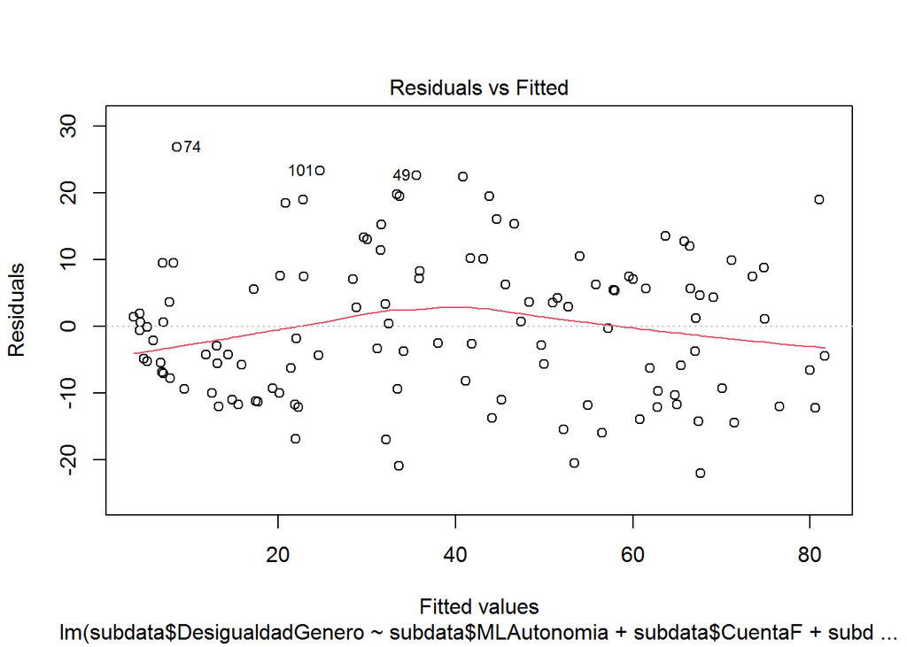

```r
# linea roja debe tender a horizontal
plot(MF3, 1)
```

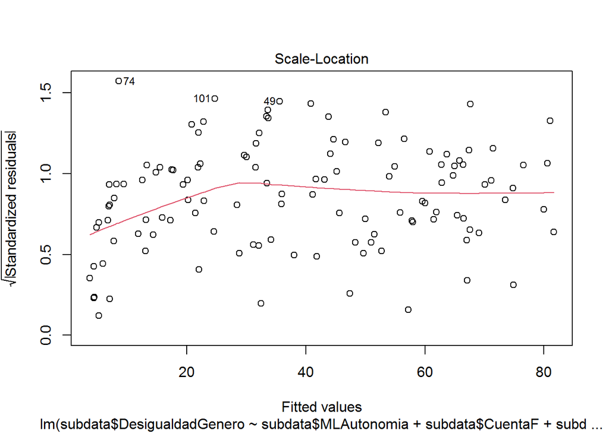

```r
# linea roja debe tender a horizontal
plot(MF3, 3)
```

También podemos utilizar el test de Breusch-Pagan:

```r
library(lmtest)
# Hnull: modelo homocedastico
bptest(MF3)
```

```
##
##  studentized Breusch-Pagan test
##
## data:  MF3
## BP = 3.1299, df = 3, p-value = 0.372
```

- La probabilidad de homocedasticidad es alta, de el modelo muestra homocedasticidad.

C. Normalidad de los residuos

Los residuos, la diferencia entre MATH y MATH^, debe distribuirse de manera normal:

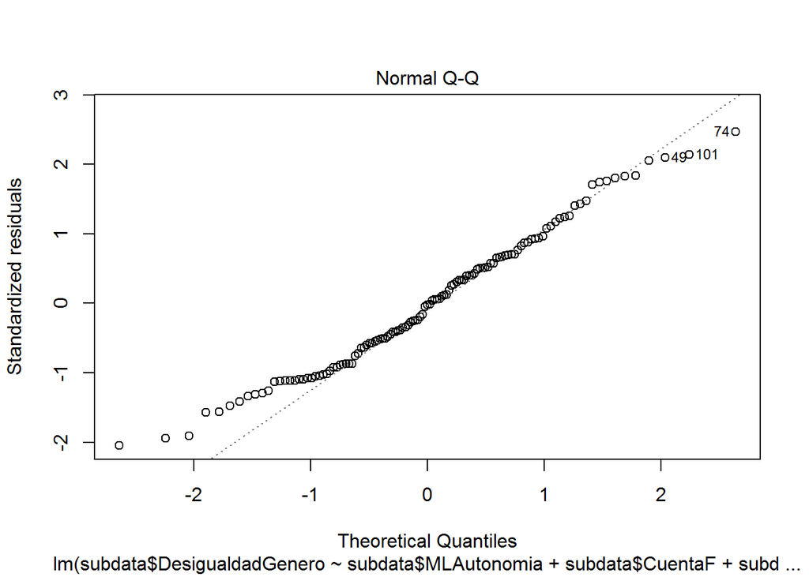

```r
# puntos cerca a la diagonal
plot(MF3, 2)
```

Podemos aplicar el test de Shapiro a los residuos:

```r
shapiro.test(MF3$residuals)
```

```
##
##  Shapiro-Wilk normality test
##
## data:  MF3$residuals
## W = 0.98101, p-value = 0.08582
```

- SI HAY UNS DISTRIBUCION NORMAL

D.No multicolinelidad - Si los predictores tienen una correlación muy alta entre sí, hay multicolinealidad, lo cual no es deseable:

```r
library(DescTools)
VIF(MF3) # > 5 es problematico
```

```
## subdata$MLAutonomia     subdata$CuentaF subdata$SecundariaC
##            1.456612            2.085549            2.237518
```

5. Valores influyentes

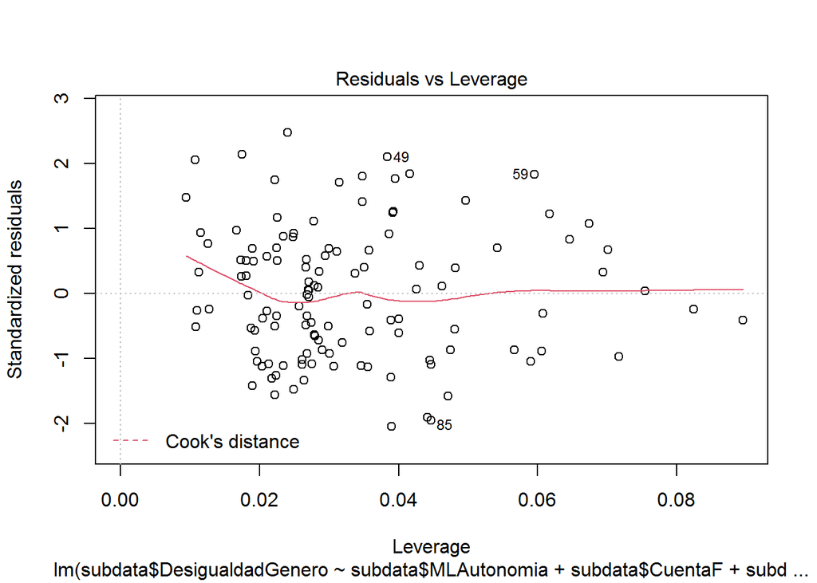

```r
plot(MF3,5)
```

RESPUESTA: segun el grafico hay un indicio que si hay tres casos influyentes pero se verificará tomando en cuenta la distancia cook y el hat.

```r
checkMF3=as.data.frame(influence.measures(MF3)$is.inf)
head(checkMF3)
```

|  | dfb.1_ | dfb.s$ML | dfb.s$CF | dfb.s$SC | dffit | cov.r | cook.d | hat |
| --- | --- | --- | --- | --- | --- | --- | --- | --- |
| 1 | FALSE | FALSE | FALSE | FALSE | FALSE | FALSE | FALSE | FALSE |
| 2 | FALSE | FALSE | FALSE | FALSE | FALSE | FALSE | FALSE | FALSE |
| 3 | FALSE | FALSE | FALSE | FALSE | FALSE | FALSE | FALSE | FALSE |
| 4 | FALSE | FALSE | FALSE | FALSE | FALSE | FALSE | FALSE | FALSE |
| 5 | FALSE | FALSE | FALSE | FALSE | FALSE | FALSE | FALSE | FALSE |
| 6 | FALSE | FALSE | FALSE | FALSE | FALSE | FALSE | FALSE | FALSE |

```r
checkMF3[checkMF3$cook.d|checkMF3$hat,]
```

| dfb.1_ | dfb.s$ML | dfb.s$CF | dfb.s$SC | dffit | cov.r | cook.d | hat |
| --- | --- | --- | --- | --- | --- | --- | --- |

RESPUESTA: no hay valores influyentes

14. COMPARACION DE MODELOS

```r
stargazer(MF1,MF2,MF3, type = "text") #TRES putnso nos dan un alto valor de significancia, el primero es el estimado o cieficiente, el entre parentesis es el error residual.
```

```
##
## ==============================================================================================
##                                                Dependent variable:
##                     --------------------------------------------------------------------------
##                                                 DesigualdadGenero
##                               (1)                      (2)                      (3)
## ----------------------------------------------------------------------------------------------
## MLAutonomia                 2.883***                 2.389***                 2.935***
##                             (0.852)                  (0.795)                  (0.856)
##
## LibertadMov                  -0.165
##                             (0.108)
##
## SecundariaC                 0.285***                 0.332***                 0.304***
##                             (0.051)                  (0.046)                  (0.050)
##
## CuentaF                     0.440***                 0.396***                 0.450***
##                             (0.050)                  (0.047)                  (0.050)
##
## VozPolitica                                          0.403***
##                                                      (0.085)
##
## Constant                     12.498                 -27.366***                 0.706
##                             (7.963)                  (6.211)                  (2.142)
##
## ----------------------------------------------------------------------------------------------
## Observations                  121                      121                      121
## R2                           0.823                    0.849                    0.819
## Adjusted R2                  0.817                    0.843                    0.814
## Residual Std. Error    10.935 (df = 116)        10.101 (df = 116)        10.998 (df = 117)
## F Statistic         134.494*** (df = 4; 116) 162.598*** (df = 4; 116) 176.484*** (df = 3; 117)
## ==============================================================================================
## Note:                                                              *p<0.1; **p<0.05; ***p<0.01
```

```r
stargazer(MF1,MF2,MF3, type = "html", title = "Modelos planteados",digits = 3, single.row = F,no.space = F,intercept.bottom = FALSE,
          dep.var.caption="Variable dependiente:",
          dep.var.labels="Desigualdad de género",
          covariate.labels=c("Constante","Marco Legal Autonomía","Libertad de Movimiento","Secundaria
                             Completa", "Cuenta Financierta","Voz Política"),
          column.labels = c("Modelo 1", "Modelo 2","Modelo 3"),
          notes.label = "Notas:")
```

[output not shown]